# Ford GoBike System Dateset

# EDA

### - Univariate Exploration

##### - 1 - Trip distribution over day hours?

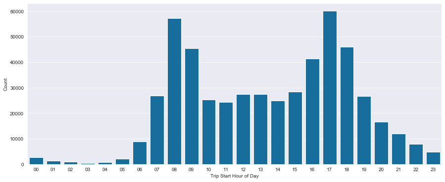

```python
# trip distribution over day hours

plt.rcParams['figure.figsize'] = 15, 6
base_color = sns.color_palette('colorblind')[0]
sns.set_style('darkgrid')

sns.countplot(data=main, x='start_hour_of_day', color=base_color);
plt.xlabel('Trip Start Hour of Day');
plt.ylabel('Count');
```

- The number of trips peaked around 8-9am and 17-18pm during a day.

##### - 2 - What is the distribution of the number of trips over the weekly?

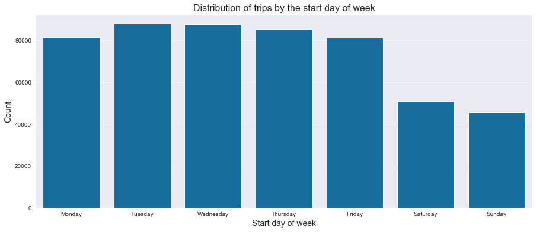

```python
# Visualizing distribution of trips by days

weekday = ['Monday', 'Tuesday', 'Wednesday', 'Thursday', 'Friday', 'Saturday', 'Sunday']
weekdaycat = pd.api.types.CategoricalDtype(ordered=True, categories=weekday)
main['start_day_of_week'] = main['start_day_of_week'].astype(weekdaycat)

sns.countplot(data=main, x='start_day_of_week', color=base_color)
plt.xlabel('Start day of week', fontsize=14)
plt.ylabel('Count', fontsize=14)
plt.title("Distribution of trips by the start day of week", fontsize=16);
```

- there were more trips on work days (Mon-Fri) compared to weekends

##### - 3 - What is the distribution of the number of trips by months?

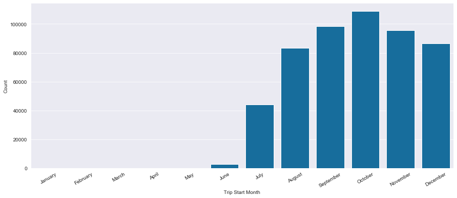

```python
# trip distribution over months

month = ['January', 'February', 'March', 'April', 'May', 'June', 'July', 'August', 'September', 'October', 'November', 'December']
monthcat = pd.api.types.CategoricalDtype(ordered=True, categories=month)
main['start_month'] = main['start_month'].astype(monthcat)

sns.countplot(data=main, x='start_month', color=base_color);
plt.xticks(rotation=30);
plt.xlabel('Trip Start Month');
plt.ylabel('Count');
```

##### - 4 - What is the proportion between different user types?

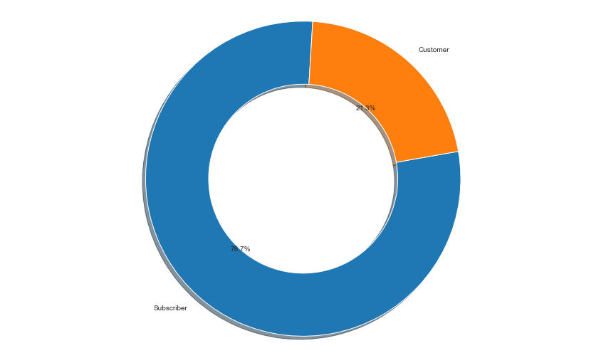

```python
#sns.countplot(data=main, x='user_type', color=base_color);
#plt.xlabel('User Type');
#plt.ylabel('Count');


sorted_count = main['user_type'].value_counts()
plt.pie(sorted_count, labels = sorted_count.index, startangle = 10, counterclock = False, wedgeprops = {'width' : 0.4},
        autopct='%1.1f%%', shadow=True);
plt.axis('equal');
```

- most User type is Subscribe base user

## - Bivariate Exploration

#### - 1 - Is there any difference in Hourly usage between type of users?

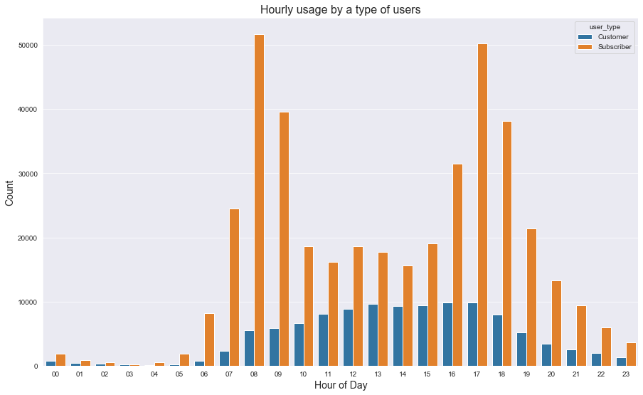

```python
# Hourly usage by a user type
plt.rcParams['figure.figsize'] = 15, 9
sns.countplot(data=main, x='start_hour_of_day', hue='user_type');
plt.xlabel('Hour of Day', fontsize=14)
plt.ylabel('Count', fontsize=14)
plt.title("Hourly usage by a type of users", fontsize=16);
```

#### - 2 - Is there any difference in weekly usage between type of users?

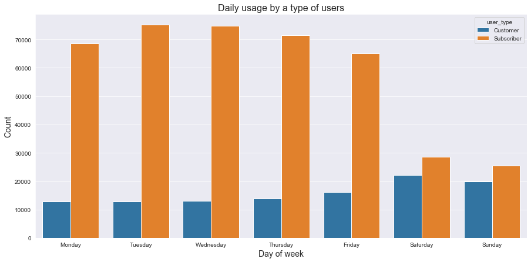

```python
# Daily usage by a user type
plt.rcParams['figure.figsize'] = 15, 7
sns.countplot(data=main, x='start_day_of_week', hue='user_type');
plt.xlabel('Day of week', fontsize=14)
plt.ylabel('Count', fontsize=14)
plt.title("Daily usage by a type of users", fontsize=16);
```

#### - 3 - Is there any difference in Monthly usage between type of users?

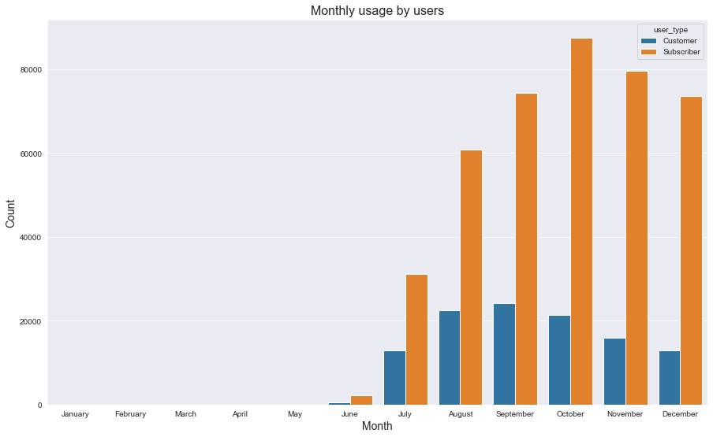

```python
# User Type and Month
plt.rcParams['figure.figsize'] = 15, 9
sns.countplot(data=main, x='start_month', hue='user_type');
plt.xlabel('Month', fontsize=14)
plt.ylabel('Count', fontsize=14)
plt.title("Monthly usage by users", fontsize=16);
```

#### - 4 - Does the average duration depend on if a user is a subscriber or customer?

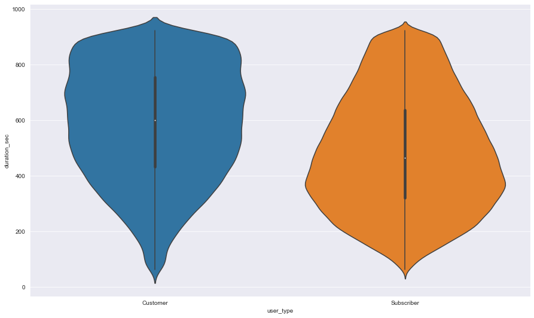

```python
sns.violinplot(data=main[main.duration_sec<=923],x='user_type',y='duration_sec');
```

## Multivariate Exploration

- Create plots of three or more variables to investigate your data even further. Make sure that your investigations are justified, and follow from your work in the previous sections.

#### - 1 - Here are some of the combinations we shall be exploring :

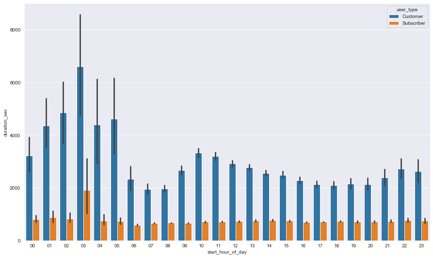

```python
sns.barplot(data=main, x='start_hour_of_day',y='duration_sec',hue='user_type');
```

#### - 2 - How does the hourly usage vary during a week for customers and subscribers?

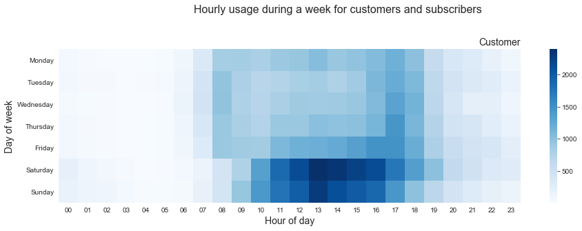

```python
plt.suptitle('Hourly usage during a week for customers and subscribers', fontsize=16)

plt.subplot(2, 1, 1)
customers = main.query('user_type == "Customer"')
ct_counts = customers.groupby(['start_day_of_week', 'start_hour_of_day']).size()
ct_counts = ct_counts.reset_index(name='count')
ct_counts = ct_counts.pivot(index='start_day_of_week', columns='start_hour_of_day', values='count')
sns.heatmap(ct_counts, cmap="Blues");
plt.title('Customer', loc='right', fontsize=14);
plt.xlabel('Hour of day', fontsize=14);
plt.ylabel('Day of week', fontsize=14);
```

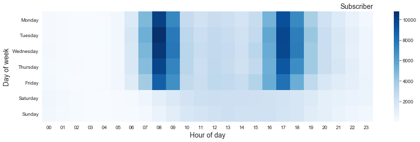

```python
plt.subplot(2, 1, 2)
subscribers = main.query('user_type == "Subscriber"')
st_counts = subscribers.groupby(['start_day_of_week', 'start_hour_of_day']).size()
st_counts = st_counts.reset_index(name='count')
st_counts = st_counts.pivot(index='start_day_of_week', columns='start_hour_of_day', values='count')
sns.heatmap(st_counts, cmap="Blues");
plt.title('Subscriber', loc='right', fontsize=14);
plt.xlabel('Hour of day', fontsize=14);
plt.ylabel('Day of week', fontsize=14);
```